# The Stroop Effect

In a Stroop task, participants are presented with a list of words, with each word displayed in a color of ink. The participant’s task is to say out loud the color of the ink in which the word is printed. The task has two conditions: a congruent words condition, and an incongruent words condition. In the congruent words condition, the words being displayed are color words whose names match the colors in which they are printed: for example RED, BLUE. In the incongruent words condition, the words displayed are color words whose names do not match the colors in which they are printed: for example PURPLE, ORANGE. In each case, we measure the time it takes to name the ink colors in equally-sized lists. Each participant will go through and record a time from each condition.

#### 1. What is our independent variable? What is our dependent variable?

The independant variable are the 2 tasks: the congruent (where color and word match) and the incongruent (where color and word do not match).

The dependant variable is the performance on each task (time in seconds needed to read the list of colored words)

#### 2. What is an appropriate set of hypotheses for this task? What kind of statistical test do you expect to perform? Justify your choices.

H_0: x_congruent - x_incongruent >= 0  
H_A: x_congruent - x_incongruent < 0 (we expect the average time needed for the congruent task to be less)

I would expect to perform a t-test with dependant samples. This experiment is a in-between subject design as the same person is asked to do both tasks. So the same person is tested with 2 different conditions.

#### 3. Report some descriptive statistics regarding this dataset. Include at least one measure of central tendency and at least one measure of variability.

```python
import pandas as pd
import math
from __future__ import division


path = r'~/Documents/GitHub/nano/source/stroopdata.csv'
dataFrame = pd.read_csv(path)
x_congruent = dataFrame['Congruent'].mean()  # 14.051
x_incongruent = dataFrame['Incongruent'].mean() #22.06
x_D = (dataFrame['Congruent'] - dataFrame['Incongruent']).mean() # -7.96
n = len(dataFrame) # 24
df = n-1 # 23
s_D = math.sqrt(sum([pow(d - x_D,2) for d in dataFrame['Congruent'] - dataFrame['Incongruent']]) / df) # 4.86
SE = s_D / math.sqrt(n) #0.993

s_congruent = math.sqrt(sum([pow(d - x_congruent,2) for d in dataFrame['Congruent']]) / df)  # 3.56
s_incongruent = math.sqrt(sum([pow(d - x_incongruent,2) for d in dataFrame['Incongruent']]) / df) #4.797
```

Mean for the congruent task: 14.05s  
Mean for the incongruent task: 22.06s  
Mean of the difference (x_congruent - x_incongruent): -7.96  
Standard deviation of the difference: 4.86  
Standard error for samples of size 24: 0.993

#### 4. Provide one or two visualizations that show the distribution of the sample data. Write one or two sentences noting what you observe about the plot or plots.

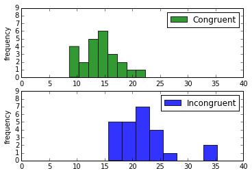

```python
# Causes plots to display within the notebook rather than in a new window
%pylab inline

import matplotlib.pyplot as plt
import numpy as np
d = dataFrame['Incongruent'] - dataFrame['Congruent']

# histogram for the congruent and incongruent task
num_bins = 8

plt.title(r'Histogram of Stroop test performance')

plt.subplot(2, 1, 1)
n, bins, patches = plt.hist(dataFrame['Congruent'], num_bins, facecolor='green', alpha=0.8, label = 'Congruent')
plt.xlim(0,40)
plt.ylim(0,9)
plt.xlabel('performance[s]')
plt.ylabel('frequency')
plt.legend()

plt.subplot(2, 1, 2)
n, bins, patches = plt.hist(dataFrame['Incongruent'], num_bins, facecolor='blue', alpha=0.8, label='Incongruent')
plt.xlim(0,40)
plt.ylim(0,9)
plt.ylabel('frequency')
plt.legend()

#plt.subplot(3, 1, 3)
#n, bins, patches = plt.hist(dataFrame['Incongruent']-dataFrame['Congruent'], num_bins, facecolor='red', alpha=0.8, label='Difference')
#plt.xlim(0,40)
#plt.ylim(0,9)
#plt.ylabel('frequency')
#plt.legend()


# Tweak spacing to prevent clipping of ylabel
plt.subplots_adjust(left=0.15)
plt.show()
```

The 2 histograms show the distribution of the participant's performance for the congruent task in green and for the incongruent task in blue. Both distributions look slightly normally distributed (with a peak in the middle, flatting at the tails), but we only have 24 data points which is very little to get a good plot.  
However, we can see a clear shift. The whole distribution shifted to right when comparing the performance for the congruent to the performance for the incongruent task. This is also backed by means that we calculated (x_congruent 14.05, x_incongruent 22.06).  
When we compare the standard deviations we find that it is smaller for the congruent task, so the distribution should be skinnier than for the incongruent task. However, that cannot really be seen in the plot.

#### 5. Now, perform the statistical test and report your results. What is your confidence level and your critical statistic value? Do you reject the null hypothesis or fail to reject it? Come to a conclusion in terms of the experiment task. Did the results match up with your expectations?

```python
# alpha level 0.05 and df = 23 for one-tailed test
t_critical = -1.714 # +/- 1.714
t_statistic = x_D / SE
t_statistic
#t_statistic < t_critical # is significant
```

```
-8.020706944109957
```

At a 0.05 alpha level for a 1-tailed test we get +/- 1.714 as the t critical value.

The t statistic is -8.02 which is smaller than -1.714, so we reject H_0.  
H_0: x_congruent - x_incongruent >= 0  
H_A: x_congruent - x_incongruent < 0

As we expected the participant's needed significantly more time for the incongruent task.

#### 6. Optional: What do you think is responsible for the effects observed? Can you think of an alternative or similar task that would result in a similar effect? Some research about the problem will be helpful for thinking about these two questions!

It is irritating when you get contradicting information. You see the color, but the word gives a different information. So you constantly have to remind yourself which part of the information you have to ignore. This is probably a conscious task, because you have to decide, and this takes longer.

A similar task could be to draw a box and then write top, bottom, left and right on the edges. When the information is congruent participants are probably faster then when it is incongruent.

#### References

http://matplotlib.org/examples/index.html http://matplotlib.org/examples/pylab_examples/subplot_demo.html http://matplotlib.org/api/pyplot_api.html https://en.wikipedia.org/wiki/Stroop_effect